# Reproducible Research: Peer Assessment 1

Loaded ggplot2 and lattice packages for graphics generation.  
Loaded plyr package for ddply function.

```r
library(ggplot2)
library(plyr)
library(lattice)
```

```r
dateTime = Sys.time()
```

This analysis was last run on 2014-07-20 16:47:24

## The Dataset used for the assignment

The data for this assignment was obtained from a personal activity monitoring  
device. Over the course of two months, October and November 2012, an anonmymous  
individual used the device to collect personal movement data that included the  
number of steps taken in 5 minute intervals each day.

The steps data for this assignment can be downloaded from Dr. Roger Peng's  
Reproducible Research course website.

- **Dataset:** [Activity monitoring data](https://d396qusza40orc.cloudfront.net/repdata%2Fdata%2Factivity.zip) [52K]

The dataset includes three variables:

1. **steps:** The number of steps that were taken by the individual in each  
   5-minute interval (missing values are represented by NA)
2. **data:** The date on which the data was acquired in YYYY-MM-DD format
3. **interval:** An identifier for the 5-minute interval in which the data was  
   acquired

The dataset is stored in a comma-separated-value (CSV) file. There are a total  
of 17,568 observations.

## Goals of the Assignment

1. What was the mean total number of steps taken per day? (Missing values not  
   imputed)
2. What was the average daily activity pattern? (Missing values not imputed)
3. What was the mean total number of steps taken per day? (Missing values  
   imputed)
4. Are there differences in activity patterns between weekdays and weekends?  
   (Missing values imputed)

## Loading and preprocessing the data

### Download data and read from csv file into data frame

While, the github repository does contain the activity data in a zip file, I  
opted to download the data from the Course website cited above and stored  
“activity.csv”“, in a directory named Steps_Data

```r
if(!file.exists("Steps_Data")) {
    dir.create("Steps_Data")
}

zipURL <- "https://d396qusza40orc.cloudfront.net/repdata%2Fdata%2Factivity.zip"
download.file(zipURL,"./Steps_Data/temp",method = "curl")

unzip("./Steps_Data/temp", exdir = "./Steps_Data/")
unlink("./Steps_Data/temp")
```

Data was read from CSV file into data frame and the head of data frame  
displayed.

```r
stepData <- read.table("./Steps_Data/activity.csv", header = TRUE, sep = ",",
                       na.strings = "NA",
                       colClasses = c("integer","character","integer"))
head(stepData)
```

```
##   steps       date interval
## 1    NA 2012-10-01        0
## 2    NA 2012-10-01        5
## 3    NA 2012-10-01       10
## 4    NA 2012-10-01       15
## 5    NA 2012-10-01       20
## 6    NA 2012-10-01       25
```

### Preprocess the data

Because dates were loaded into the data frame with class "character”, it was  
necessary to convert them to Date objects

```r
stepData$date <- as.Date(stepData$date)
```

## What is mean total number of steps taken per day?

Before Generating a histogram of the total number of steps taken per day,  
ddply() was used to apply the sum function to the data frame subsetted by date.

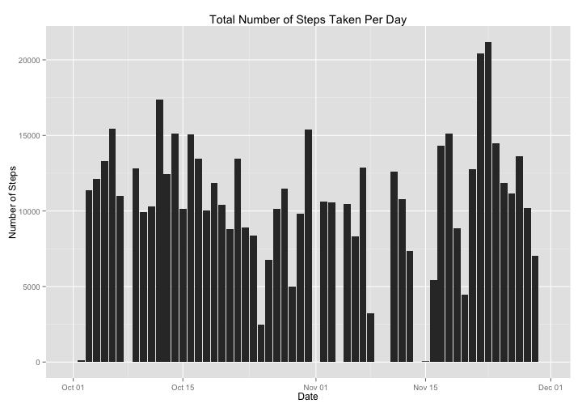

```r
totalSteps <- ddply(stepData, c("date"),summarize,
                    Frequency = sum(steps, na.rm = TRUE))

grob <- ggplot(totalSteps, aes(x = date, y = Frequency))
grob <- grob + geom_bar(stat = "identity")
grob + labs( title = "Total Number of Steps Taken Per Day",
                     x = "Date", y = "Number of Steps")
```

The mean total number of steps taken per day was calculated.

```r
mean(totalSteps$Frequency)
```

```
## [1] 9354
```

The median total number of steps taken pre day was calculated.

```r
median(totalSteps$Frequency)
```

```
## [1] 10395
```

## What is the average daily activity pattern?

Before Generating a time series of the mean number of steps taken per interval,  
ddply() was used to apply the mean function to the data frame subsetted by  
the 5-minute intervals.

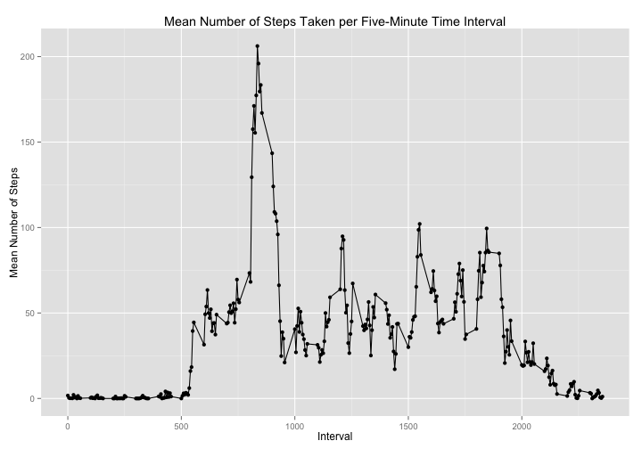

```r
meanSPI <- ddply(stepData, c("interval"),summarise,
                 mean = mean(steps, na.rm = TRUE))

timeGrob <- ggplot(meanSPI, aes(x = interval, y = mean))
timeGrob <- timeGrob + geom_line() + geom_point()
timeGrob + labs(title = "Mean Number of Steps Taken per Five-Minute Time Interval",
                x = "Interval", y = "Mean Number of Steps")
```

The 5-interval across all days in the datataset which contains the maximum  
number of steps taken was determined.

```r
meanSPI$interval[which.max(meanSPI$mean)]
```

```
## [1] 835
```

## Imputing missing values

Before devising a reasonable strategy for imputing the missing data values,  
the distribution of missing values(NAs) in the data set was determined.

The total number of missing values in the data set was calculated.

```r
sum(is.na(stepData$steps))
```

```
## [1] 2304
```

The percentage of missing values in the data set was calculated.

```r
sum(is.na(stepData$steps))/length(stepData$steps)
```

```
## [1] 0.1311
```

The percentage of NA values for each date was calculated.

```r
dailyNAs <- ddply(stepData, c("date"),summarize,
                  percent_NA = 100 * sum(is.na(steps))/length(steps))

day_of_week <- weekdays(dailyNAs$date)
dailyNAs <- cbind(day_of_week, dailyNAs)
print(dailyNAs)
```

```
##    day_of_week       date percent_NA
## 1       Monday 2012-10-01        100
## 2      Tuesday 2012-10-02          0
## 3    Wednesday 2012-10-03          0
## 4     Thursday 2012-10-04          0
## 5       Friday 2012-10-05          0
## 6     Saturday 2012-10-06          0
## 7       Sunday 2012-10-07          0
## 8       Monday 2012-10-08        100
## 9      Tuesday 2012-10-09          0
## 10   Wednesday 2012-10-10          0
## 11    Thursday 2012-10-11          0
## 12      Friday 2012-10-12          0
## 13    Saturday 2012-10-13          0
## 14      Sunday 2012-10-14          0
```

[output cut: 47 more lines]

A brief examination of the the dailyNAs data frame (above) revealed that each  
date has either all missing values (100%) or no missing values (0%).  
Out of the 61 dates, there are 8 dates for which all of the values are missing.  
Two of these dates fall on a Monday, two on a Friday, and one each on Wednesday,  
Thursday,Saturday, and Sunday. Based on these results, the following imputation  
strategy was devised:

If the number of steps for a five-minute interval is missing, the imputed value  
will be the mean of the five-minute interval for that particular day (e.g. if  
the missing value occurs at interval 4 on a Sunday,the imputed value will be the  
mean number of steps for interval 4's that occurred on Sundays).

The first step in the imputation process was to generate values that could be  
used for imputation. It was noted that for each day of the week, the steps were  
counted for 288 five-minute intervals. It was therefore necessary to generate  
means for the 288 intervals that occured on Sundays, the 288 intervals that  
occured on Mondays, etc. Therefore 288 * 7 = 2016 means were generated. Note,  
although there are no missing Tuesday values, mean values for Tuesday intervals  
were still calculated.

```r
day <- factor(
    weekdays(stepData$date),
    c("Monday","Tuesday","Wednesday","Thursday","Friday","Saturday","Sunday"))
stepData <- cbind(day,stepData)
imputationFrame <- ddply(stepData, c("day","interval"), summarize,
                          mean = mean(steps, na.rm = TRUE))
```

Data collection began on 2012-10-01, a Monday, and ended on 2012-11-30, a  
Friday. Data was collected for 61 days with the steps recorded for 288  
five-minute intervals each day for a total of 17568 observations. The imputation  
table contains the means of the 288 intervals for each of the 7 days  
(Monday- Sunday) resulting in 2016 rows. To vectorize the missing value  
replacement operation, a vector of length 17568 from the imputationFrame's  
mean number of steps column was created.

```r
impVec <- c(rep(imputationFrame$mean, times = 8),imputationFrame$mean[1:1440])
```

Missing value in the step data were replaceds with imputed values.

```r
stepData$steps[is.na(stepData$steps)] <- impVec[is.na(stepData$steps)]
```

Before Generating a histogram of the total number of steps taken per day,  
ddply() was used to apply the sum function to the data frame subsetted by date.

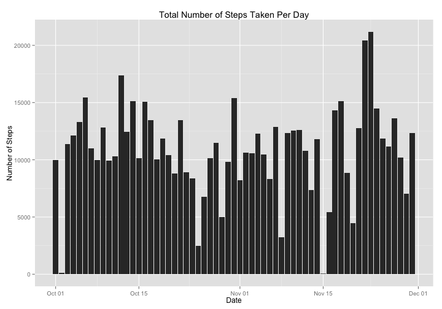

```r
totalSteps <- ddply(stepData, c("date"),summarize,
                    Frequency = sum(steps, na.rm = TRUE))

grob <- ggplot(totalSteps, aes(x = date, y = Frequency))
grob <- grob + geom_bar(stat = "identity")
grob + labs( title = "Total Number of Steps Taken Per Day",
                     x = "Date", y = "Number of Steps")
```

The mean total number of steps taken per day was calclated.

```r
mean(totalSteps$Frequency)
```

```
## [1] 10821
```

The median total number of steps taken per day was calculated.

```r
median(totalSteps$Frequency)
```

```
## [1] 11015
```

To calculate the mean, the total number of steps taken each day are summed and  
divided by the number of days (61). Prior to imputation, the 8 days composed  
entirely of NAs contributed nothing to the numerator. After imputation, each of  
these 8 days contributed positvely to the numerator. Therefore, the mean  
estimated after imputation is greater than the mean estimated before imputation.

## Are there differences in activity patterns between weekdays and weekends?

A new factor variable, “day”, with two levels - “weekday” and “weekend” was  
created.

```r
stepData$day <- as.character(stepData$day)
stepData$day <- ifelse((stepData$day == "Saturday") | (stepData$day == "Sunday")
                       ,"weekend","weekday")
stepData$day <- factor(stepData$day)
```

Before genearting a time series plot of the five-minute interval and the average  
number of steps taken (averaged across all weekday days or weekend days),  
ddply() was used to apply the mean function to the data subsetted by type of day  
(weekend or weekday), and time interval.

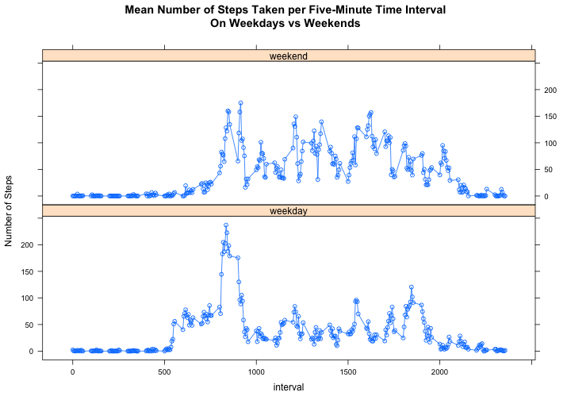

```r
meanSPI_weekend_vs_weekday <- ddply(stepData, c("day","interval"),summarise,
                 mean = mean(steps))

xyplot(mean ~ interval | day, data = meanSPI_weekend_vs_weekday, type = "b",
       main = "Mean Number of Steps Taken per Five-Minute Time Interval\nOn Weekdays vs Weekends",
       ylab = "Number of Steps", layout = c(1,2))
```